# W3cubDocs

/Matplotlib 3.1

# matplotlib.figure.Figure

**`class matplotlib.figure.Figure(figsize=None, dpi=None, facecolor=None, edgecolor=None, linewidth=0.0, frameon=None, subplotpars=None, tight_layout=None, constrained_layout=None)` [[source]](https://matplotlib.org/3.1.1/_modules/matplotlib/figure.html#Figure)**

Bases: `matplotlib.artist.Artist`

The top level container for all the plot elements.

The Figure instance supports callbacks through a *callbacks* attribute which is a `CallbackRegistry` instance. The events you can connect to are 'dpi_changed', and the callback will be called with `func(fig)` where fig is the `Figure` instance.

[output not shown]

Parameters:

**`figsize : 2-tuple of floats, default: rcParams["figure.figsize"]`**

Figure dimension `(width, height)` in inches.

**`dpi : float, default: rcParams["figure.dpi"]`**

Dots per inch.

**`facecolor : default: rcParams["figure.facecolor"]`**

The figure patch facecolor.

**`edgecolor : default: rcParams["figure.edgecolor"]`**

The figure patch edge color.

**`linewidth : float`**

The linewidth of the frame (i.e. the edge linewidth of the figure patch).

**`frameon : bool, default: rcParams["figure.frameon"]`**

If `False`, suppress drawing the figure background patch.

**`subplotpars : SubplotParams`**

Subplot parameters. If not given, the default subplot parameters `rcParams["figure.subplot.*"]` are used.

**`tight_layout : bool or dict, default: rcParams["figure.autolayout"]`**

If `False` use *subplotpars*. If `True` adjust subplot parameters using `tight_layout` with default padding. When providing a dict containing the keys `pad`, `w_pad`, `h_pad`, and `rect`, the default `tight_layout` paddings will be overridden.

**`constrained_layout : bool`**

If `True` use constrained layout to adjust positioning of plot elements. Like `tight_layout`, but designed to be more flexible. See [Constrained Layout Guide](https://matplotlib.org/3.1.1/tutorials/intermediate/constrainedlayout_guide.html) for examples. (Note: does not work with `subplot()` or `subplot2grid()`.) Defaults to `rcParams["figure.constrained_layout.use"]`.

**`add_artist(self, artist, clip=False)` [[source]](https://matplotlib.org/3.1.1/_modules/matplotlib/figure.html#Figure.add_artist)**

Add any `Artist` to the figure.

Usually artists are added to axes objects using `matplotlib.axes.Axes.add_artist()`, but use this method in the rare cases that adding directly to the figure is necessary.

[output not shown]

**`add_axes(self, *args, **kwargs)` [[source]](https://matplotlib.org/3.1.1/_modules/matplotlib/figure.html#Figure.add_axes)**

Add an axes to the figure.

Call signatures:

```
add_axes(rect, projection=None, polar=False, **kwargs)
add_axes(ax)
```

[output not shown]

See also

**`Figure.add_subplot`**

**`pyplot.subplot`**

**`pyplot.axes`**

**`Figure.subplots`**

**`pyplot.subplots`**

#### Notes

If the figure already has an axes with key (*args*, *kwargs*) then it will simply make that axes current and return it. This behavior is deprecated. Meanwhile, if you do not want this behavior (i.e., you want to force the creation of a new axes), you must use a unique set of args and kwargs. The axes *label* attribute has been exposed for this purpose: if you want two axes that are otherwise identical to be added to the figure, make sure you give them unique labels.

In rare circumstances, `add_axes` may be called with a single argument, a axes instance already created in the present figure but not in the figure's list of axes.

#### Examples

Some simple examples:

```
rect = l, b, w, h
fig = plt.figure()
fig.add_axes(rect,label=label1)
fig.add_axes(rect,label=label2)
fig.add_axes(rect, frameon=False, facecolor='g')
fig.add_axes(rect, polar=True)
ax=fig.add_axes(rect, projection='polar')
fig.delaxes(ax)
fig.add_axes(ax)
```

**`add_axobserver(self, func)` [[source]](https://matplotlib.org/3.1.1/_modules/matplotlib/figure.html#Figure.add_axobserver)**

Whenever the axes state change, `func(self)` will be called.

**`add_gridspec(self, nrows, ncols, **kwargs)` [[source]](https://matplotlib.org/3.1.1/_modules/matplotlib/figure.html#Figure.add_gridspec)**

Return a `GridSpec` that has this figure as a parent. This allows complex layout of axes in the figure.

| Parameters: | **`nrows : int`** Number of rows in grid. **`ncols : int`** Number or columns in grid. |
| --- | --- |
| Returns: | **`gridspec : GridSpec`** |
| Other Parameters: | **kwargs** Keyword arguments are passed to `GridSpec`. |

See also

**`matplotlib.pyplot.subplots`**

#### Examples

Adding a subplot that spans two rows:

```
fig = plt.figure()
gs = fig.add_gridspec(2, 2)
ax1 = fig.add_subplot(gs[0, 0])
ax2 = fig.add_subplot(gs[1, 0])
# spans two rows:
ax3 = fig.add_subplot(gs[:, 1])
```

**`add_subplot(self, *args, **kwargs)` [[source]](https://matplotlib.org/3.1.1/_modules/matplotlib/figure.html#Figure.add_subplot)**

Add an `Axes` to the figure as part of a subplot arrangement.

Call signatures:

```
add_subplot(nrows, ncols, index, **kwargs)
add_subplot(pos, **kwargs)
add_subplot(ax)
add_subplot()
```

[output not shown]

See also

**`Figure.add_axes`**

**`pyplot.subplot`**

**`pyplot.axes`**

**`Figure.subplots`**

**`pyplot.subplots`**

#### Notes

If the figure already has a subplot with key (*args*, *kwargs*) then it will simply make that subplot current and return it. This behavior is deprecated. Meanwhile, if you do not want this behavior (i.e., you want to force the creation of a new subplot), you must use a unique set of args and kwargs. The axes *label* attribute has been exposed for this purpose: if you want two subplots that are otherwise identical to be added to the figure, make sure you give them unique labels.

#### Examples

```
fig = plt.figure()
fig.add_subplot(221)

# equivalent but more general
ax1 = fig.add_subplot(2, 2, 1)

# add a subplot with no frame
ax2 = fig.add_subplot(222, frameon=False)

# add a polar subplot
fig.add_subplot(223, projection='polar')

# add a red subplot that share the x-axis with ax1
fig.add_subplot(224, sharex=ax1, facecolor='red')

#delete x2 from the figure
fig.delaxes(ax2)

#add x2 to the figure again
fig.add_subplot(ax2)
```

**`align_labels(self, axs=None)` [[source]](https://matplotlib.org/3.1.1/_modules/matplotlib/figure.html#Figure.align_labels)**

Align the xlabels and ylabels of subplots with the same subplots row or column (respectively) if label alignment is being done automatically (i.e. the label position is not manually set).

Alignment persists for draw events after this is called.

| Parameters: | **`axs : list of Axes`** Optional list (or ndarray) of `Axes` to align the labels. Default is to align all axes on the figure. |
| --- | --- |

See also

**`matplotlib.figure.Figure.align_xlabels`**

**`matplotlib.figure.Figure.align_ylabels`**

**`align_xlabels(self, axs=None)` [[source]](https://matplotlib.org/3.1.1/_modules/matplotlib/figure.html#Figure.align_xlabels)**

Alignment persists for draw events after this is called.

If a label is on the bottom, it is aligned with labels on axes that also have their label on the bottom and that have the same bottom-most subplot row. If the label is on the top, it is aligned with labels on axes with the same top-most row.

| Parameters: | **`axs : list of Axes`** Optional list of (or ndarray) `Axes` to align the xlabels. Default is to align all axes on the figure. |
| --- | --- |

See also

**`matplotlib.figure.Figure.align_ylabels`**

**`matplotlib.figure.Figure.align_labels`**

#### Notes

This assumes that `axs` are from the same `GridSpec`, so that their `SubplotSpec` positions correspond to figure positions.

#### Examples

Example with rotated xtick labels:

```
fig, axs = plt.subplots(1, 2)
for tick in axs[0].get_xticklabels():
    tick.set_rotation(55)
axs[0].set_xlabel('XLabel 0')
axs[1].set_xlabel('XLabel 1')
fig.align_xlabels()
```

**`align_ylabels(self, axs=None)` [[source]](https://matplotlib.org/3.1.1/_modules/matplotlib/figure.html#Figure.align_ylabels)**

Align the ylabels of subplots in the same subplot column if label alignment is being done automatically (i.e. the label position is not manually set).

Alignment persists for draw events after this is called.

If a label is on the left, it is aligned with labels on axes that also have their label on the left and that have the same left-most subplot column. If the label is on the right, it is aligned with labels on axes with the same right-most column.

| Parameters: | **`axs : list of Axes`** Optional list (or ndarray) of `Axes` to align the ylabels. Default is to align all axes on the figure. |
| --- | --- |

See also

**`matplotlib.figure.Figure.align_xlabels`**

**`matplotlib.figure.Figure.align_labels`**

#### Notes

This assumes that `axs` are from the same `GridSpec`, so that their `SubplotSpec` positions correspond to figure positions.

#### Examples

Example with large yticks labels:

```
fig, axs = plt.subplots(2, 1)
axs[0].plot(np.arange(0, 1000, 50))
axs[0].set_ylabel('YLabel 0')
axs[1].set_ylabel('YLabel 1')
fig.align_ylabels()
```

**`autofmt_xdate(self, bottom=0.2, rotation=30, ha='right', which=None)` [[source]](https://matplotlib.org/3.1.1/_modules/matplotlib/figure.html#Figure.autofmt_xdate)**

Date ticklabels often overlap, so it is useful to rotate them and right align them. Also, a common use case is a number of subplots with shared xaxes where the x-axis is date data. The ticklabels are often long, and it helps to rotate them on the bottom subplot and turn them off on other subplots, as well as turn off xlabels.

[output not shown]

**`axes`**

List of axes in the Figure. You can access the axes in the Figure through this list. Do not modify the list itself. Instead, use `add_axes`, `subplot` or `delaxes` to add or remove an axes.

**`clear(self, keep_observers=False)` [[source]](https://matplotlib.org/3.1.1/_modules/matplotlib/figure.html#Figure.clear)**

Clear the figure -- synonym for `clf()`.

**`clf(self, keep_observers=False)` [[source]](https://matplotlib.org/3.1.1/_modules/matplotlib/figure.html#Figure.clf)**

Clear the figure.

Set *keep_observers* to True if, for example, a gui widget is tracking the axes in the figure.

**`colorbar(self, mappable, cax=None, ax=None, use_gridspec=True, **kw)` [[source]](https://matplotlib.org/3.1.1/_modules/matplotlib/figure.html#Figure.colorbar)**

Create a colorbar for a ScalarMappable instance, *mappable*.

Documentation for the pyplot thin wrapper:

Add a colorbar to a plot.

Function signatures for the `pyplot` interface; all but the first are also method signatures for the `colorbar()` method:

```
colorbar(**kwargs)
colorbar(mappable, **kwargs)
colorbar(mappable, cax=cax, **kwargs)
colorbar(mappable, ax=ax, **kwargs)
```

Parameters:

**mappable**

The `matplotlib.cm.ScalarMappable` (i.e., `Image`, `ContourSet`, etc.) described by this colorbar. This argument is mandatory for the `Figure.colorbar` method but optional for the `pyplot.colorbar` function, which sets the default to the current image.

Note that one can create a `ScalarMappable` "on-the-fly" to generate colorbars not attached to a previously drawn artist, e.g.

```
fig.colorbar(cm.ScalarMappable(norm=norm, cmap=cmap), ax=ax)
```

**`cax : Axes object, optional`**

Axes into which the colorbar will be drawn.

**`ax : Axes, list of Axes, optional`**

Parent axes from which space for a new colorbar axes will be stolen. If a list of axes is given they will all be resized to make room for the colorbar axes.

**`use_gridspec : bool, optional`**

If *cax* is `None`, a new *cax* is created as an instance of Axes. If *ax* is an instance of Subplot and *use_gridspec* is `True`, *cax* is created as an instance of Subplot using the `gridspec` module.

Returns:

**`colorbar : Colorbar`**

See also its base class, `ColorbarBase`. Use `set_label` to label the colorbar.

#### Notes

Additional keyword arguments are of two kinds:

axes properties:

| Property | Description |
| --- | --- |
| *orientation* | vertical or horizontal |
| *fraction* | 0.15; fraction of original axes to use for colorbar |
| *pad* | 0.05 if vertical, 0.15 if horizontal; fraction of original axes between colorbar and new image axes |
| *shrink* | 1.0; fraction by which to multiply the size of the colorbar |
| *aspect* | 20; ratio of long to short dimensions |
| *anchor* | (0.0, 0.5) if vertical; (0.5, 1.0) if horizontal; the anchor point of the colorbar axes |
| *panchor* | (1.0, 0.5) if vertical; (0.5, 0.0) if horizontal; the anchor point of the colorbar parent axes. If False, the parent axes' anchor will be unchanged |

colorbar properties:

[output not shown]

The following will probably be useful only in the context of indexed colors (that is, when the mappable has norm=NoNorm()), or other unusual circumstances.

[output not shown]

If *mappable* is a `ContourSet`, its *extend* kwarg is included automatically.

The *shrink* kwarg provides a simple way to scale the colorbar with respect to the axes. Note that if *cax* is specified, it determines the size of the colorbar and *shrink* and *aspect* kwargs are ignored.

For more precise control, you can manually specify the positions of the axes objects in which the mappable and the colorbar are drawn. In this case, do not use any of the axes properties kwargs.

It is known that some vector graphics viewers (svg and pdf) renders white gaps between segments of the colorbar. This is due to bugs in the viewers, not Matplotlib. As a workaround, the colorbar can be rendered with overlapping segments:

```
cbar = colorbar()
cbar.solids.set_edgecolor("face")
draw()
```

However this has negative consequences in other circumstances, e.g. with semi-transparent images (alpha < 1) and colorbar extensions; therefore, this workaround is not used by default (see issue #1188).

**`contains(self, mouseevent)` [[source]](https://matplotlib.org/3.1.1/_modules/matplotlib/figure.html#Figure.contains)**

Test whether the mouse event occurred on the figure.

| Returns: | **bool, {}** |
| --- | --- |

**`delaxes(self, ax)` [[source]](https://matplotlib.org/3.1.1/_modules/matplotlib/figure.html#Figure.delaxes)**

Remove the `Axes` *ax* from the figure and update the current axes.

**`dpi`**

The resolution in dots per inch.

**`draw(self, renderer)` [[source]](https://matplotlib.org/3.1.1/_modules/matplotlib/figure.html#Figure.draw)**

Render the figure using `matplotlib.backend_bases.RendererBase` instance *renderer*.

**`draw_artist(self, a)` [[source]](https://matplotlib.org/3.1.1/_modules/matplotlib/figure.html#Figure.draw_artist)**

Draw `matplotlib.artist.Artist` instance *a* only. This is available only after the figure is drawn.

**`execute_constrained_layout(self, renderer=None)` [[source]](https://matplotlib.org/3.1.1/_modules/matplotlib/figure.html#Figure.execute_constrained_layout)**

Use `layoutbox` to determine pos positions within axes.

See also `set_constrained_layout_pads`.

**`figimage(self, X, xo=0, yo=0, alpha=None, norm=None, cmap=None, vmin=None, vmax=None, origin=None, resize=False, **kwargs)` [[source]](https://matplotlib.org/3.1.1/_modules/matplotlib/figure.html#Figure.figimage)**

Add a non-resampled image to the figure.

The image is attached to the lower or upper left corner depending on *origin*.

Parameters:

**X**

The image data. This is an array of one of the following shapes:

- MxN: luminance (grayscale) values
- MxNx3: RGB values
- MxNx4: RGBA values

**`xo, yo : int`**

The *x*/*y* image offset in pixels.

**`alpha : None or float`**

The alpha blending value.

**`norm : matplotlib.colors.Normalize`**

A `Normalize` instance to map the luminance to the interval [0, 1].

**`cmap : str or matplotlib.colors.Colormap`**

The colormap to use. Default: `rcParams["image.cmap"]`.

**`vmin, vmax : scalar`**

If *norm* is not given, these values set the data limits for the colormap.

**`origin : {'upper', 'lower'}`**

Indicates where the [0, 0] index of the array is in the upper left or lower left corner of the axes. Defaults to `rcParams["image.origin"]`.

**`resize : bool`**

If *True*, resize the figure to match the given image size.

Returns:

**`matplotlib.image.FigureImage`**

Other Parameters:

**kwargs**

Additional kwargs are `Artist` kwargs passed on to `FigureImage`.

#### Notes

figimage complements the axes image (`imshow()`) which will be resampled to fit the current axes. If you want a resampled image to fill the entire figure, you can define an `Axes` with extent [0,0,1,1].

Examples:

```
f = plt.figure()
nx = int(f.get_figwidth() * f.dpi)
ny = int(f.get_figheight() * f.dpi)
data = np.random.random((ny, nx))
f.figimage(data)
plt.show()
```

**`frameon`**

Return the figure's background patch visibility, i.e. whether the figure background will be drawn. Equivalent to `Figure.patch.get_visible()`.

**`gca(self, **kwargs)` [[source]](https://matplotlib.org/3.1.1/_modules/matplotlib/figure.html#Figure.gca)**

Get the current axes, creating one if necessary.

The following kwargs are supported for ensuring the returned axes adheres to the given projection etc., and for axes creation if the active axes does not exist:

| Property | Description |
| --- | --- |
| `adjustable` | {'box', 'datalim'} |
| `agg_filter` | a filter function, which takes a (m, n, 3) float array and a dpi value, and returns a (m, n, 3) array |
| `alpha` | float |
| `anchor` | 2-tuple of floats or {'C', 'SW', 'S', 'SE', ...} |
| `animated` | bool |
| `aspect` | {'auto', 'equal'} or num |
| `autoscale_on` | bool |
| `autoscalex_on` | bool |
| `autoscaley_on` | bool |
| `axes_locator` | Callable[[Axes, Renderer], Bbox] |
| `axisbelow` | bool or 'line' |
| `clip_box` | `Bbox` |
| `clip_on` | bool |
| `clip_path` | [(`Path`, `Transform`) \| `Patch` \| None] |
| `contains` | callable |
| `facecolor` | color |
| `fc` | color |
| `figure` | `Figure` |
| `frame_on` | bool |
| `gid` | str |
| `in_layout` | bool |
| `label` | object |
| `navigate` | bool |
| `navigate_mode` | unknown |
| `path_effects` | `AbstractPathEffect` |
| `picker` | None or bool or float or callable |
| `position` | [left, bottom, width, height] or `Bbox` |
| `rasterization_zorder` | float or None |
| `rasterized` | bool or None |
| `sketch_params` | (scale: float, length: float, randomness: float) |
| `snap` | bool or None |
| `title` | str |
| `transform` | `Transform` |
| `url` | str |
| `visible` | bool |
| `xbound` | unknown |
| `xlabel` | str |
| `xlim` | (left: float, right: float) |
| `xmargin` | float greater than -0.5 |
| `xscale` | {"linear", "log", "symlog", "logit", ...} |
| `xticklabels` | List[str] |
| `xticks` | list |
| `ybound` | unknown |
| `ylabel` | str |
| `ylim` | (bottom: float, top: float) |
| `ymargin` | float greater than -0.5 |
| `yscale` | {"linear", "log", "symlog", "logit", ...} |
| `yticklabels` | List[str] |
| `yticks` | list |
| `zorder` | float |

**`get_axes(self)` [[source]](https://matplotlib.org/3.1.1/_modules/matplotlib/figure.html#Figure.get_axes)**

Return a list of axes in the Figure. You can access and modify the axes in the Figure through this list.

Do not modify the list itself. Instead, use `add_axes`, `subplot` or `delaxes` to add or remove an axes.

Note: This is equivalent to the property `axes`.

**`get_children(self)` [[source]](https://matplotlib.org/3.1.1/_modules/matplotlib/figure.html#Figure.get_children)**

Get a list of artists contained in the figure.

**`get_constrained_layout(self)` [[source]](https://matplotlib.org/3.1.1/_modules/matplotlib/figure.html#Figure.get_constrained_layout)**

Return a boolean: True means constrained layout is being used.

See [Constrained Layout Guide](https://matplotlib.org/3.1.1/tutorials/intermediate/constrainedlayout_guide.html).

**`get_constrained_layout_pads(self, relative=False)` [[source]](https://matplotlib.org/3.1.1/_modules/matplotlib/figure.html#Figure.get_constrained_layout_pads)**

Get padding for `constrained_layout`.

Returns a list of `w_pad, h_pad` in inches and `wspace` and `hspace` as fractions of the subplot.

See [Constrained Layout Guide](https://matplotlib.org/3.1.1/tutorials/intermediate/constrainedlayout_guide.html).

| Parameters: | **`relative : boolean`** If [`True`](https://docs.python.org/3/library/constants.html#True), then convert from inches to figure relative. |
| --- | --- |

**`get_default_bbox_extra_artists(self)` [[source]](https://matplotlib.org/3.1.1/_modules/matplotlib/figure.html#Figure.get_default_bbox_extra_artists)**

**`get_dpi(self)` [[source]](https://matplotlib.org/3.1.1/_modules/matplotlib/figure.html#Figure.get_dpi)**

Return the resolution in dots per inch as a float.

**`get_edgecolor(self)` [[source]](https://matplotlib.org/3.1.1/_modules/matplotlib/figure.html#Figure.get_edgecolor)**

Get the edge color of the Figure rectangle.

**`get_facecolor(self)` [[source]](https://matplotlib.org/3.1.1/_modules/matplotlib/figure.html#Figure.get_facecolor)**

Get the face color of the Figure rectangle.

**`get_figheight(self)` [[source]](https://matplotlib.org/3.1.1/_modules/matplotlib/figure.html#Figure.get_figheight)**

Return the figure height as a float.

**`get_figwidth(self)` [[source]](https://matplotlib.org/3.1.1/_modules/matplotlib/figure.html#Figure.get_figwidth)**

Return the figure width as a float.

**`get_frameon(self)` [[source]](https://matplotlib.org/3.1.1/_modules/matplotlib/figure.html#Figure.get_frameon)**

Return the figure's background patch visibility, i.e. whether the figure background will be drawn. Equivalent to `Figure.patch.get_visible()`.

**`get_size_inches(self)` [[source]](https://matplotlib.org/3.1.1/_modules/matplotlib/figure.html#Figure.get_size_inches)**

Returns the current size of the figure in inches.

| Returns: | **`size : ndarray`** The size (width, height) of the figure in inches. |
| --- | --- |

See also

**`matplotlib.Figure.set_size_inches`**

**`get_tight_layout(self)` [[source]](https://matplotlib.org/3.1.1/_modules/matplotlib/figure.html#Figure.get_tight_layout)**

Return whether `tight_layout` is called when drawing.

**`get_tightbbox(self, renderer, bbox_extra_artists=None)` [[source]](https://matplotlib.org/3.1.1/_modules/matplotlib/figure.html#Figure.get_tightbbox)**

Return a (tight) bounding box of the figure in inches.

Artists that have `artist.set_in_layout(False)` are not included in the bbox.

[output not shown]

**`get_window_extent(self, *args, **kwargs)` [[source]](https://matplotlib.org/3.1.1/_modules/matplotlib/figure.html#Figure.get_window_extent)**

Return the figure bounding box in display space. Arguments are ignored.

**`ginput(self, n=1, timeout=30, show_clicks=True, mouse_add=1, mouse_pop=3, mouse_stop=2)` [[source]](https://matplotlib.org/3.1.1/_modules/matplotlib/figure.html#Figure.ginput)**

Blocking call to interact with a figure.

Wait until the user clicks *n* times on the figure, and return the coordinates of each click in a list.

There are three possible interactions:

- Add a point.
- Remove the most recently added point.
- Stop the interaction and return the points added so far.

The actions are assigned to mouse buttons via the arguments *mouse_add*, *mouse_pop* and *mouse_stop*. Mouse buttons are defined by the numbers:

- 1: left mouse button
- 2: middle mouse button
- 3: right mouse button
- None: no mouse button

[output not shown]

#### Notes

The keyboard can also be used to select points in case your mouse does not have one or more of the buttons. The delete and backspace keys act like right clicking (i.e., remove last point), the enter key terminates input and any other key (not already used by the window manager) selects a point.

**`init_layoutbox(self)` [[source]](https://matplotlib.org/3.1.1/_modules/matplotlib/figure.html#Figure.init_layoutbox)**

Initialize the layoutbox for use in constrained_layout.

**`legend(self, *args, **kwargs)` [[source]](https://matplotlib.org/3.1.1/_modules/matplotlib/figure.html#Figure.legend)**

Place a legend on the figure.

To make a legend from existing artists on every axes:

```
legend()
```

To make a legend for a list of lines and labels:

```
legend(
    (line1, line2, line3),
    ('label1', 'label2', 'label3'),
    loc='upper right')
```

These can also be specified by keyword:

```
legend(
    handles=(line1, line2, line3),
    labels=('label1', 'label2', 'label3'),
    loc='upper right')
```

Parameters:

**`handles : sequence of Artist, optional`**

A list of Artists (lines, patches) to be added to the legend. Use this together with *labels*, if you need full control on what is shown in the legend and the automatic mechanism described above is not sufficient.

The length of handles and labels should be the same in this case. If they are not, they are truncated to the smaller length.

**`labels : sequence of strings, optional`**

A list of labels to show next to the artists. Use this together with *handles*, if you need full control on what is shown in the legend and the automatic mechanism described above is not sufficient.

Returns:

**`matplotlib.legend.Legend instance`**

Other Parameters:

**`loc : str or pair of floats, default: rcParams["legend.loc"] ('best' for axes, 'upper right' for figures)`**

The location of the legend.

The strings `'upper left', 'upper right', 'lower left', 'lower right'` place the legend at the corresponding corner of the axes/figure.

The strings `'upper center', 'lower center', 'center left', 'center right'` place the legend at the center of the corresponding edge of the axes/figure.

The string `'center'` places the legend at the center of the axes/figure.

The string `'best'` places the legend at the location, among the nine locations defined so far, with the minimum overlap with other drawn artists. This option can be quite slow for plots with large amounts of data; your plotting speed may benefit from providing a specific location.

The location can also be a 2-tuple giving the coordinates of the lower-left corner of the legend in axes coordinates (in which case *bbox_to_anchor* will be ignored).

For back-compatibility, `'center right'` (but no other location) can also be spelled `'right'`, and each "string" locations can also be given as a numeric value:

| Location String | Location Code |
| --- | --- |
| 'best' | 0 |
| 'upper right' | 1 |
| 'upper left' | 2 |
| 'lower left' | 3 |
| 'lower right' | 4 |
| 'right' | 5 |
| 'center left' | 6 |
| 'center right' | 7 |
| 'lower center' | 8 |
| 'upper center' | 9 |
| 'center' | 10 |

**`bbox_to_anchor : BboxBase, 2-tuple, or 4-tuple of floats`**

Box that is used to position the legend in conjunction with *loc*. Defaults to `axes.bbox` (if called as a method to `Axes.legend`) or `figure.bbox` (if `Figure.legend`). This argument allows arbitrary placement of the legend.

Bbox coordinates are interpreted in the coordinate system given by `bbox_transform`, with the default transform Axes or Figure coordinates, depending on which `legend` is called.

If a 4-tuple or `BboxBase` is given, then it specifies the bbox `(x, y, width, height)` that the legend is placed in. To put the legend in the best location in the bottom right quadrant of the axes (or figure):

```
loc='best', bbox_to_anchor=(0.5, 0., 0.5, 0.5)
```

A 2-tuple `(x, y)` places the corner of the legend specified by *loc* at x, y. For example, to put the legend's upper right-hand corner in the center of the axes (or figure) the following keywords can be used:

```
loc='upper right', bbox_to_anchor=(0.5, 0.5)
```

**`ncol : integer`**

The number of columns that the legend has. Default is 1.

**`prop : None or matplotlib.font_manager.FontProperties or dict`**

The font properties of the legend. If None (default), the current `matplotlib.rcParams` will be used.

**`fontsize : int or float or {'xx-small', 'x-small', 'small', 'medium', 'large', 'x-large', 'xx-large'}`**

Controls the font size of the legend. If the value is numeric the size will be the absolute font size in points. String values are relative to the current default font size. This argument is only used if `prop` is not specified.

**`numpoints : None or int`**

The number of marker points in the legend when creating a legend entry for a `Line2D` (line). Default is `None`, which will take the value from `rcParams["legend.numpoints"]`.

**`scatterpoints : None or int`**

The number of marker points in the legend when creating a legend entry for a `PathCollection` (scatter plot). Default is `None`, which will take the value from `rcParams["legend.scatterpoints"]`.

**`scatteryoffsets : iterable of floats`**

The vertical offset (relative to the font size) for the markers created for a scatter plot legend entry. 0.0 is at the base the legend text, and 1.0 is at the top. To draw all markers at the same height, set to `[0.5]`. Default is `[0.375, 0.5, 0.3125]`.

**`markerscale : None or int or float`**

The relative size of legend markers compared with the originally drawn ones. Default is `None`, which will take the value from `rcParams["legend.markerscale"]`.

**`markerfirst : bool`**

If *True*, legend marker is placed to the left of the legend label. If *False*, legend marker is placed to the right of the legend label. Default is *True*.

**`frameon : None or bool`**

Control whether the legend should be drawn on a patch (frame). Default is `None`, which will take the value from `rcParams["legend.frameon"]`.

**`fancybox : None or bool`**

Control whether round edges should be enabled around the `FancyBboxPatch` which makes up the legend's background. Default is `None`, which will take the value from `rcParams["legend.fancybox"]`.

**`shadow : None or bool`**

Control whether to draw a shadow behind the legend. Default is `None`, which will take the value from `rcParams["legend.shadow"]`.

**`framealpha : None or float`**

Control the alpha transparency of the legend's background. Default is `None`, which will take the value from `rcParams["legend.framealpha"]`. If shadow is activated and *framealpha* is `None`, the default value is ignored.

**`facecolor : None or "inherit" or a color spec`**

Control the legend's background color. Default is `None`, which will take the value from `rcParams["legend.facecolor"]`. If `"inherit"`, it will take `rcParams["axes.facecolor"]`.

**`edgecolor : None or "inherit" or a color spec`**

Control the legend's background patch edge color. Default is `None`, which will take the value from `rcParams["legend.edgecolor"]` If `"inherit"`, it will take `rcParams["axes.edgecolor"]`.

**`mode : {"expand", None}`**

If `mode` is set to `"expand"` the legend will be horizontally expanded to fill the axes area (or `bbox_to_anchor` if defines the legend's size).

**`bbox_transform : None or matplotlib.transforms.Transform`**

The transform for the bounding box (`bbox_to_anchor`). For a value of `None` (default) the Axes' `transAxes` transform will be used.

**`title : str or None`**

The legend's title. Default is no title (`None`).

**title_fontsize: str or None**

The fontsize of the legend's title. Default is the default fontsize.

**`borderpad : float or None`**

The fractional whitespace inside the legend border. Measured in font-size units. Default is `None`, which will take the value from `rcParams["legend.borderpad"]`.

**`labelspacing : float or None`**

The vertical space between the legend entries. Measured in font-size units. Default is `None`, which will take the value from `rcParams["legend.labelspacing"]`.

**`handlelength : float or None`**

The length of the legend handles. Measured in font-size units. Default is `None`, which will take the value from `rcParams["legend.handlelength"]`.

**`handletextpad : float or None`**

The pad between the legend handle and text. Measured in font-size units. Default is `None`, which will take the value from `rcParams["legend.handletextpad"]`.

**`borderaxespad : float or None`**

The pad between the axes and legend border. Measured in font-size units. Default is `None`, which will take the value from `rcParams["legend.borderaxespad"]`.

**`columnspacing : float or None`**

The spacing between columns. Measured in font-size units. Default is `None`, which will take the value from `rcParams["legend.columnspacing"]`.

**`handler_map : dict or None`**

The custom dictionary mapping instances or types to a legend handler. This `handler_map` updates the default handler map found at `matplotlib.legend.Legend.get_legend_handler_map()`.

#### Notes

Not all kinds of artist are supported by the legend command. See [Legend guide](https://matplotlib.org/3.1.1/tutorials/intermediate/legend_guide.html) for details.

**`savefig(self, fname, *, transparent=None, **kwargs)` [[source]](https://matplotlib.org/3.1.1/_modules/matplotlib/figure.html#Figure.savefig)**

Save the current figure.

Call signature:

```
savefig(fname, dpi=None, facecolor='w', edgecolor='w',
        orientation='portrait', papertype=None, format=None,
        transparent=False, bbox_inches=None, pad_inches=0.1,
        frameon=None, metadata=None)
```

The output formats available depend on the backend being used.

Parameters:

**`fname : str or PathLike or file-like object`**

A path, or a Python file-like object, or possibly some backend-dependent object such as `matplotlib.backends.backend_pdf.PdfPages`.

If *format* is not set, then the output format is inferred from the extension of *fname*, if any, and from `rcParams["savefig.format"]` otherwise. If *format* is set, it determines the output format.

Hence, if *fname* is not a path or has no extension, remember to specify *format* to ensure that the correct backend is used.

Other Parameters:

**`dpi : [ None | scalar > 0 | 'figure' ]`**

The resolution in dots per inch. If *None*, defaults to `rcParams["savefig.dpi"]`. If 'figure', uses the figure's dpi value.

**`quality : [ None | 1 <= scalar <= 100 ]`**

The image quality, on a scale from 1 (worst) to 95 (best). Applicable only if *format* is jpg or jpeg, ignored otherwise. If *None*, defaults to `rcParams["savefig.jpeg_quality"]` (95 by default). Values above 95 should be avoided; 100 completely disables the JPEG quantization stage.

**`optimize : bool`**

If *True*, indicates that the JPEG encoder should make an extra pass over the image in order to select optimal encoder settings. Applicable only if *format* is jpg or jpeg, ignored otherwise. Is *False* by default.

**`progressive : bool`**

If *True*, indicates that this image should be stored as a progressive JPEG file. Applicable only if *format* is jpg or jpeg, ignored otherwise. Is *False* by default.

**`facecolor : color spec or None, optional`**

The facecolor of the figure; if *None*, defaults to `rcParams["savefig.facecolor"]`.

**`edgecolor : color spec or None, optional`**

The edgecolor of the figure; if *None*, defaults to `rcParams["savefig.edgecolor"]`

**`orientation : {'landscape', 'portrait'}`**

Currently only supported by the postscript backend.

**`papertype : str`**

One of 'letter', 'legal', 'executive', 'ledger', 'a0' through 'a10', 'b0' through 'b10'. Only supported for postscript output.

**`format : str`**

The file format, e.g. 'png', 'pdf', 'svg', ... The behavior when this is unset is documented under *fname*.

**`transparent : bool`**

If *True*, the axes patches will all be transparent; the figure patch will also be transparent unless facecolor and/or edgecolor are specified via kwargs. This is useful, for example, for displaying a plot on top of a colored background on a web page. The transparency of these patches will be restored to their original values upon exit of this function.

**`bbox_inches : str or Bbox, optional`**

Bbox in inches. Only the given portion of the figure is saved. If 'tight', try to figure out the tight bbox of the figure. If None, use savefig.bbox

**`pad_inches : scalar, optional`**

Amount of padding around the figure when bbox_inches is 'tight'. If None, use savefig.pad_inches

**`bbox_extra_artists : list of Artist, optional`**

A list of extra artists that will be considered when the tight bbox is calculated.

**`metadata : dict, optional`**

Key/value pairs to store in the image metadata. The supported keys and defaults depend on the image format and backend:

- 'png' with Agg backend: See the parameter `metadata` of `print_png`.
- 'pdf' with pdf backend: See the parameter `metadata` of `PdfPages`.
- 'eps' and 'ps' with PS backend: Only 'Creator' is supported.

**`pil_kwargs : dict, optional`**

Additional keyword arguments that are passed to `PIL.Image.save` when saving the figure. Only applicable for formats that are saved using Pillow, i.e. JPEG, TIFF, and (if the keyword is set to a non-None value) PNG.

**`sca(self, a)` [[source]](https://matplotlib.org/3.1.1/_modules/matplotlib/figure.html#Figure.sca)**

Set the current axes to be a and return a.

**`set_canvas(self, canvas)` [[source]](https://matplotlib.org/3.1.1/_modules/matplotlib/figure.html#Figure.set_canvas)**

Set the canvas that contains the figure

| Parameters: | **`canvas : FigureCanvas`** |
| --- | --- |

**`set_constrained_layout(self, constrained)` [[source]](https://matplotlib.org/3.1.1/_modules/matplotlib/figure.html#Figure.set_constrained_layout)**

Set whether `constrained_layout` is used upon drawing. If None, the rcParams['figure.constrained_layout.use'] value will be used.

When providing a dict containing the keys `w_pad`, `h_pad` the default `constrained_layout` paddings will be overridden. These pads are in inches and default to 3.0/72.0. `w_pad` is the width padding and `h_pad` is the height padding.

See [Constrained Layout Guide](https://matplotlib.org/3.1.1/tutorials/intermediate/constrainedlayout_guide.html).

| Parameters: | **`constrained : bool or dict or None`** |
| --- | --- |

**`set_constrained_layout_pads(self, **kwargs)` [[source]](https://matplotlib.org/3.1.1/_modules/matplotlib/figure.html#Figure.set_constrained_layout_pads)**

Set padding for `constrained_layout`. Note the kwargs can be passed as a dictionary `fig.set_constrained_layout(**paddict)`.

See [Constrained Layout Guide](https://matplotlib.org/3.1.1/tutorials/intermediate/constrainedlayout_guide.html).

Parameters:

**`w_pad : scalar`**

Width padding in inches. This is the pad around axes and is meant to make sure there is enough room for fonts to look good. Defaults to 3 pts = 0.04167 inches

**`h_pad : scalar`**

Height padding in inches. Defaults to 3 pts.

**`wspace : scalar`**

Width padding between subplots, expressed as a fraction of the subplot width. The total padding ends up being w_pad + wspace.

**`hspace : scalar`**

Height padding between subplots, expressed as a fraction of the subplot width. The total padding ends up being h_pad + hspace.

**`set_dpi(self, val)` [[source]](https://matplotlib.org/3.1.1/_modules/matplotlib/figure.html#Figure.set_dpi)**

Set the resolution of the figure in dots-per-inch.

| Parameters: | **`val : float`** |
| --- | --- |

**`set_edgecolor(self, color)` [[source]](https://matplotlib.org/3.1.1/_modules/matplotlib/figure.html#Figure.set_edgecolor)**

Set the edge color of the Figure rectangle.

| Parameters: | **`color : color`** |
| --- | --- |

**`set_facecolor(self, color)` [[source]](https://matplotlib.org/3.1.1/_modules/matplotlib/figure.html#Figure.set_facecolor)**

Set the face color of the Figure rectangle.

| Parameters: | **`color : color`** |
| --- | --- |

**`set_figheight(self, val, forward=True)` [[source]](https://matplotlib.org/3.1.1/_modules/matplotlib/figure.html#Figure.set_figheight)**

Set the height of the figure in inches.

| Parameters: | **`val : float`** **`forward : bool`** |
| --- | --- |

**`set_figwidth(self, val, forward=True)` [[source]](https://matplotlib.org/3.1.1/_modules/matplotlib/figure.html#Figure.set_figwidth)**

Set the width of the figure in inches.

| Parameters: | **`val : float`** **`forward : bool`** |
| --- | --- |

**`set_frameon(self, b)` [[source]](https://matplotlib.org/3.1.1/_modules/matplotlib/figure.html#Figure.set_frameon)**

Set the figure's background patch visibility, i.e. whether the figure background will be drawn. Equivalent to `Figure.patch.set_visible()`.

| Parameters: | **`b : bool`** |
| --- | --- |

**`set_size_inches(self, w, h=None, forward=True)` [[source]](https://matplotlib.org/3.1.1/_modules/matplotlib/figure.html#Figure.set_size_inches)**

Set the figure size in inches.

Call signatures:

```
fig.set_size_inches(w, h)  # OR
fig.set_size_inches((w, h))
```

optional kwarg *forward=True* will cause the canvas size to be automatically updated; e.g., you can resize the figure window from the shell

ACCEPTS: a (w, h) tuple with w, h in inches

See also

**`matplotlib.Figure.get_size_inches`**

**`set_tight_layout(self, tight)` [[source]](https://matplotlib.org/3.1.1/_modules/matplotlib/figure.html#Figure.set_tight_layout)**

Set whether and how `tight_layout` is called when drawing.

[output not shown]

**`show(self, warn=True)` [[source]](https://matplotlib.org/3.1.1/_modules/matplotlib/figure.html#Figure.show)**

If using a GUI backend with pyplot, display the figure window.

If the figure was not created using `figure()`, it will lack a `FigureManagerBase`, and will raise an AttributeError.

Warning

This does not manage an GUI event loop. Consequently, the figure may only be shown briefly or not shown at all if you or your environment are not managing an event loop.

Proper use cases for `Figure.show` include running this from a GUI application or an IPython shell.

If you're running a pure python shell or executing a non-GUI python script, you should use `matplotlib.pyplot.show` instead, which takes care of managing the event loop for you.

| Parameters: | **`warn : bool`** If `True` and we are not running headless (i.e. on Linux with an unset DISPLAY), issue warning when called on a non-GUI backend. |
| --- | --- |

**`subplots(self, nrows=1, ncols=1, sharex=False, sharey=False, squeeze=True, subplot_kw=None, gridspec_kw=None)` [[source]](https://matplotlib.org/3.1.1/_modules/matplotlib/figure.html#Figure.subplots)**

Add a set of subplots to this figure.

This utility wrapper makes it convenient to create common layouts of subplots in a single call.

Parameters:

**`nrows, ncols : int, optional, default: 1`**

Number of rows/columns of the subplot grid.

**`sharex, sharey : bool or {'none', 'all', 'row', 'col'}, default: False`**

Controls sharing of properties among x (`sharex`) or y (`sharey`) axes:

- True or 'all': x- or y-axis will be shared among all subplots.
- False or 'none': each subplot x- or y-axis will be independent.
- 'row': each subplot row will share an x- or y-axis.
- 'col': each subplot column will share an x- or y-axis.

When subplots have a shared x-axis along a column, only the x tick labels of the bottom subplot are created. Similarly, when subplots have a shared y-axis along a row, only the y tick labels of the first column subplot are created. To later turn other subplots' ticklabels on, use `tick_params`.

**`squeeze : bool, optional, default: True`**

- If True, extra dimensions are squeezed out from the returned array of Axes:
  - if only one subplot is constructed (nrows=ncols=1), the resulting single Axes object is returned as a scalar.
  - for Nx1 or 1xM subplots, the returned object is a 1D numpy object array of Axes objects.
  - for NxM, subplots with N>1 and M>1 are returned as a 2D array.
- If False, no squeezing at all is done: the returned Axes object is always a 2D array containing Axes instances, even if it ends up being 1x1.

**`subplot_kw : dict, optional`**

Dict with keywords passed to the `add_subplot()` call used to create each subplot.

**`gridspec_kw : dict, optional`**

Dict with keywords passed to the `GridSpec` constructor used to create the grid the subplots are placed on.

Returns:

**`ax : Axes object or array of Axes objects.`**

*ax* can be either a single `Axes` object or an array of Axes objects if more than one subplot was created. The dimensions of the resulting array can be controlled with the squeeze keyword, see above.

#### Examples

```
# First create some toy data:
x = np.linspace(0, 2*np.pi, 400)
y = np.sin(x**2)

# Create a figure
plt.figure()

# Creates a subplot
ax = fig.subplots()
ax.plot(x, y)
ax.set_title('Simple plot')

# Creates two subplots and unpacks the output array immediately
ax1, ax2 = fig.subplots(1, 2, sharey=True)
ax1.plot(x, y)
ax1.set_title('Sharing Y axis')
ax2.scatter(x, y)

# Creates four polar axes, and accesses them through the
# returned array
axes = fig.subplots(2, 2, subplot_kw=dict(polar=True))
axes[0, 0].plot(x, y)
axes[1, 1].scatter(x, y)

# Share a X axis with each column of subplots
fig.subplots(2, 2, sharex='col')

# Share a Y axis with each row of subplots
fig.subplots(2, 2, sharey='row')

# Share both X and Y axes with all subplots
fig.subplots(2, 2, sharex='all', sharey='all')

# Note that this is the same as
fig.subplots(2, 2, sharex=True, sharey=True)
```

**`subplots_adjust(self, left=None, bottom=None, right=None, top=None, wspace=None, hspace=None)` [[source]](https://matplotlib.org/3.1.1/_modules/matplotlib/figure.html#Figure.subplots_adjust)**

Update the `SubplotParams` with *kwargs* (defaulting to rc when *None*) and update the subplot locations.

**`suptitle(self, t, **kwargs)` [[source]](https://matplotlib.org/3.1.1/_modules/matplotlib/figure.html#Figure.suptitle)**

Add a centered title to the figure.

[output not shown]

#### Examples

```
>>> fig.suptitle('This is the figure title', fontsize=12)
```

**`text(self, x, y, s, fontdict=None, withdash=<deprecated parameter>, **kwargs)` [[source]](https://matplotlib.org/3.1.1/_modules/matplotlib/figure.html#Figure.text)**

Add text to figure.

[output not shown]

See also

**`Axes.text`**

**`pyplot.text`**

**`tight_layout(self, renderer=None, pad=1.08, h_pad=None, w_pad=None, rect=None)` [[source]](https://matplotlib.org/3.1.1/_modules/matplotlib/figure.html#Figure.tight_layout)**

Automatically adjust subplot parameters to give specified padding.

To exclude an artist on the axes from the bounding box calculation that determines the subplot parameters (i.e. legend, or annotation), then set `a.set_in_layout(False)` for that artist.

Parameters:

**`renderer : subclass of RendererBase, optional`**

Defaults to the renderer for the figure.

**`pad : float, optional`**

Padding between the figure edge and the edges of subplots, as a fraction of the font size.

**`h_pad, w_pad : float, optional`**

Padding (height/width) between edges of adjacent subplots, as a fraction of the font size. Defaults to *pad*.

**`rect : tuple (left, bottom, right, top), optional`**

A rectangle (left, bottom, right, top) in the normalized figure coordinate that the whole subplots area (including labels) will fit into. Default is (0, 0, 1, 1).

See also

**`Figure.set_tight_layout`**

**`pyplot.tight_layout`**

**`waitforbuttonpress(self, timeout=-1)` [[source]](https://matplotlib.org/3.1.1/_modules/matplotlib/figure.html#Figure.waitforbuttonpress)**

Blocking call to interact with the figure.

This will return True is a key was pressed, False if a mouse button was pressed and None if *timeout* was reached without either being pressed.

If *timeout* is negative, does not timeout.

## Examples using `matplotlib.figure.Figure`

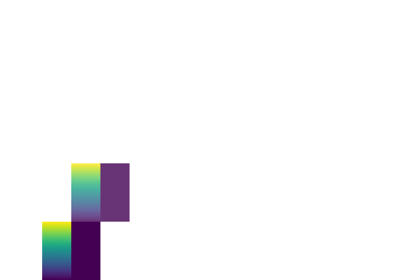

[Figimage Demo](https://matplotlib.org/3.1.1/gallery/images_contours_and_fields/figimage_demo.html#sphx-glr-gallery-images-contours-and-fields-figimage-demo-py)

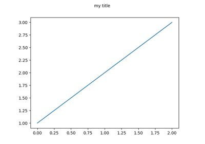

[Custom Figure Class](https://matplotlib.org/3.1.1/gallery/subplots_axes_and_figures/custom_figure_class.html#sphx-glr-gallery-subplots-axes-and-figures-custom-figure-class-py)

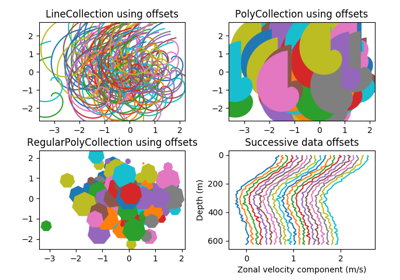

[Line, Poly and RegularPoly Collection with autoscaling](https://matplotlib.org/3.1.1/gallery/shapes_and_collections/collections.html#sphx-glr-gallery-shapes-and-collections-collections-py)

[CanvasAgg demo](https://matplotlib.org/3.1.1/gallery/user_interfaces/canvasagg.html#sphx-glr-gallery-user-interfaces-canvasagg-py)

[Embedding in GTK3 with a navigation toolbar](https://matplotlib.org/3.1.1/gallery/user_interfaces/embedding_in_gtk3_panzoom_sgskip.html#sphx-glr-gallery-user-interfaces-embedding-in-gtk3-panzoom-sgskip-py)

[Embedding in GTK3](https://matplotlib.org/3.1.1/gallery/user_interfaces/embedding_in_gtk3_sgskip.html#sphx-glr-gallery-user-interfaces-embedding-in-gtk3-sgskip-py)

[Embedding in Qt](https://matplotlib.org/3.1.1/gallery/user_interfaces/embedding_in_qt_sgskip.html#sphx-glr-gallery-user-interfaces-embedding-in-qt-sgskip-py)

[Embedding in Tk](https://matplotlib.org/3.1.1/gallery/user_interfaces/embedding_in_tk_sgskip.html#sphx-glr-gallery-user-interfaces-embedding-in-tk-sgskip-py)

[Embedding in wx #2](https://matplotlib.org/3.1.1/gallery/user_interfaces/embedding_in_wx2_sgskip.html#sphx-glr-gallery-user-interfaces-embedding-in-wx2-sgskip-py)

[Embedding in wx #3](https://matplotlib.org/3.1.1/gallery/user_interfaces/embedding_in_wx3_sgskip.html#sphx-glr-gallery-user-interfaces-embedding-in-wx3-sgskip-py)

[Embedding in wx #4](https://matplotlib.org/3.1.1/gallery/user_interfaces/embedding_in_wx4_sgskip.html#sphx-glr-gallery-user-interfaces-embedding-in-wx4-sgskip-py)

[Embedding in wx #5](https://matplotlib.org/3.1.1/gallery/user_interfaces/embedding_in_wx5_sgskip.html#sphx-glr-gallery-user-interfaces-embedding-in-wx5-sgskip-py)

[Embedding WebAgg](https://matplotlib.org/3.1.1/gallery/user_interfaces/embedding_webagg_sgskip.html#sphx-glr-gallery-user-interfaces-embedding-webagg-sgskip-py)

[Fourier Demo WX](https://matplotlib.org/3.1.1/gallery/user_interfaces/fourier_demo_wx_sgskip.html#sphx-glr-gallery-user-interfaces-fourier-demo-wx-sgskip-py)

[GTK Spreadsheet](https://matplotlib.org/3.1.1/gallery/user_interfaces/gtk_spreadsheet_sgskip.html#sphx-glr-gallery-user-interfaces-gtk-spreadsheet-sgskip-py)

[MathText WX](https://matplotlib.org/3.1.1/gallery/user_interfaces/mathtext_wx_sgskip.html#sphx-glr-gallery-user-interfaces-mathtext-wx-sgskip-py)

[Matplotlib With Glade 3](https://matplotlib.org/3.1.1/gallery/user_interfaces/mpl_with_glade3_sgskip.html#sphx-glr-gallery-user-interfaces-mpl-with-glade3-sgskip-py)

[WXcursor Demo](https://matplotlib.org/3.1.1/gallery/user_interfaces/wxcursor_demo_sgskip.html#sphx-glr-gallery-user-interfaces-wxcursor-demo-sgskip-py)

[Pyplot tutorial](https://matplotlib.org/3.1.1/tutorials/introductory/pyplot.html#sphx-glr-tutorials-introductory-pyplot-py)

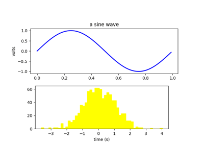

[Artist tutorial](https://matplotlib.org/3.1.1/tutorials/intermediate/artists.html#sphx-glr-tutorials-intermediate-artists-py)

[The mplot3d Toolkit](https://matplotlib.org/3.1.1/tutorials/toolkits/mplot3d.html#sphx-glr-tutorials-toolkits-mplot3d-py)

© 2012–2018 Matplotlib Development Team. All rights reserved.  
Licensed under the Matplotlib License Agreement.  
https://matplotlib.org/3.1.1/api/_as_gen/matplotlib.figure.Figure.html